# PhenolyzerR Vignette

Jonah Einson

PhenolyzerR is an R implementation of Phenolyzer, which prioritizes genes related to an input disease term. The tool leverages the tree structure of the Disease Ontology (DO) and CTD Medical ontology to extend a query term. It then uses three different knowledge bases (OMIM, ClinVar, and GWAS) to match the extended search term and generate prioritized diseaes.

To install it:

```r
library(devtools)
install_github("jeinson/PhenolyzerR")
```

```
## Skipping install of 'PhenolyzerR' from a github remote, the SHA1 (184abad8) has not changed since last install.
##   Use `force = TRUE` to force installation
```

```r
library(PhenolyzerR)
```

To illustrate PhenolyzerR’s functionality, begin by extending the term “alzheimer”

```r
alzheimer_terms <- disease_extension("alzheimer")
```

```
## Finished searching the Disease Ontology Database
```

```
## Finished searching the CTD Medic Database
```

```r
alzheimer_terms[1:75,]
```

| Disease | Source |
| --- | --- |
| alzheimer | MY_TERM |
| Alzheimer's disease 2 | DISEASE_ONTOLOGY |
| Alzheimer's disease 16 | DISEASE_ONTOLOGY |
| Alzheimer's disease 5 | DISEASE_ONTOLOGY |
| Alzheimer's disease 6 | DISEASE_ONTOLOGY |
| Alzheimer's disease 7 | DISEASE_ONTOLOGY |
| Alzheimer's disease 4 | DISEASE_ONTOLOGY |
| Alzheimer's disease 8 | DISEASE_ONTOLOGY |
| Alzheimer's disease 3 | DISEASE_ONTOLOGY |
| Alzheimer's disease 10 | DISEASE_ONTOLOGY |

[output cut: 65 more lines]

Notice that this function automatically downloaded the CTD and DO ontology files, and placed them in your local environment. The output is conveniently in a tibble format, which is easier (or less painful) to work with than a data.frame.

Next, try outputting a prioritized gene list.

```r
output_gene_prioritization("alzheimer's disease")
```

```
## Finished searching the Disease Ontology Database
```

```
## Finished searching the CTD Medic Database
```

```
## Disease term extension completed
```

```
## Fixing synonymous gene names across databases
```

```
## Done!
```

```
## Matching to database with extended terms!
```

```
## Matching to database with input term!
```

| GeneID | GENE | reported_SCORE |
| --- | --- | --- |
| 348 | APOE | 1.00000000 |
| 10452 | TOMM40 | 0.42940822 |
| 2 | A2M | 0.39924454 |
| 10347 | ABCA7 | 0.24798817 |
| 274 | BIN1 | 0.22576227 |
| 5663 | PSEN1 | 0.21776975 |
| 3077 | HFE | 0.20567143 |
| 4353 | MPO | 0.20567143 |
| 8301 | PICALM | 0.20561663 |
| 5819 | NECTIN2 | 0.19554385 |

[output cut: 393 more lines]

Again, this function downloads the OMIM genemap, ClinVar disease-gene associations file, and GWAS gene conditions associations file. This is done by calling the `build_disease_gene_associations` function, which retrieves the tables from the web, then puts them in a convenient format. This huge gene-disease tibble is saved as `DB_COMPILED_GENE_DISEASE_SCORES`. It could be used in other applications linking diseases to genes with some level of certainty.

```r
DB_COMPILED_GENE_DISEASE_SCORES[1:100,]
```

| GENE | DISEASE | DISEASE_ID | SCORE | SOURCE |
| --- | --- | --- | --- | --- |
| CCV | Cataract 8 multiple types | OMIM:115665 | 0.75 | OMIM |
| ENO1 | Enolase deficiency | OMIM:172430 | 1.00 | OMIM |
| HMGCL | HMGCoA lyase deficiency | OMIM:613898 | 0.75 | OMIM |
| AGRN | Myasthenic syndrome congenital 8 | OMIM:103320 | 0.75 | OMIM |
| GNB1 | Leukemia acute lymphoblastic somatic | OMIM:139380 | 1.00 | OMIM |
| GNB1 | Mental retardation autosomal dominant 42 | OMIM:139380 | 1.00 | OMIM |
| SDC3 | Obesity association | OMIM:186357 | 1.00 | OMIM |
| ATAD3A | HarelYoon syndrome | OMIM:612316 | 0.75 | OMIM |
| ISG15 | Immunodeficiency 38 | OMIM:147571 | 0.75 | OMIM |
| TMEM240 | Spinocerebellar ataxia 21 | OMIM:616101 | 1.00 | OMIM |

[output cut: 90 more lines]

To view what sourcce each gene prediction came from, pass `output_mode = "list"` in `output_gene_prioritization`

```r
BT_list_output <- output_gene_prioritization("beta thalassemia", output_mode = "list")
```

```
## Finished searching the Disease Ontology Database
```

```
## Finished searching the CTD Medic Database
```

```
## Disease term extension completed
```

```
## Matching to database with extended terms!
```

```
## Matching to database with input term!
```

```r
BT_list_output[1:5]
```

```
## $`KRT89P Raw score: 2.1875 Normalized score: 0.999771480804387`
## # A tibble: 5 x 5
##   GENE   DISEASE                                 DISEASE_ID   SCORE SOURCE
##   <chr>  <chr>                                   <chr>        <dbl> <chr>
## 1 KRT89P Thalassemias beta                       OMIM:141900 1      OMIM
## 2 KRT89P Beta-thalassemia, dominant inclusion b~ OMIM:603902 0.0625 ClinV~
## 3 KRT89P beta Thalassemia                        OMIM:613985 0.0625 ClinV~
## 4 KRT89P Deltabeta thalassemia                   OMIM:141900 1      OMIM
## 5 KRT89P beta Thalassemia                        OMIM:613985 0.0625 ClinV~
##
## $`HBBP1 Raw score: 0.249999999999999 Normalized score: 0.114259597806215`
## # A tibble: 1 x 5
##   GENE  DISEASE                               DISEASE_ID      SCORE SOURCE
##   <chr> <chr>                                 <chr>           <dbl> <chr>
## 1 HBBP1 Beta thalassemia/hemoglobin E disease PUBMED:20183929 0.250 GWAS
##
## $`HBE1 Raw score: 0.249999999999999 Normalized score: 0.114259597806215`
## # A tibble: 1 x 5
##   GENE  DISEASE                               DISEASE_ID      SCORE SOURCE
##   <chr> <chr>                                 <chr>           <dbl> <chr>
## 1 HBE1  Beta thalassemia/hemoglobin E disease PUBMED:20183929 0.250 GWAS
##
## $`HBG1 Raw score: 0.249999999999999 Normalized score: 0.114259597806215`
## # A tibble: 1 x 5
##   GENE  DISEASE                               DISEASE_ID      SCORE SOURCE
##   <chr> <chr>                                 <chr>           <dbl> <chr>
## 1 HBG1  Beta thalassemia/hemoglobin E disease PUBMED:20183929 0.250 GWAS
##
## $`HBG2 Raw score: 0.249999999999999 Normalized score: 0.114259597806215`
## # A tibble: 1 x 5
##   GENE  DISEASE                               DISEASE_ID      SCORE SOURCE
##   <chr> <chr>                                 <chr>           <dbl> <chr>
## 1 HBG2  Beta thalassemia/hemoglobin E disease PUBMED:20183929 0.250 GWAS
```

The output of this command can be saved in a more convenient format to work with as such:

```r
write_gene_list(BT_list_output, "BT_list_output.txt")
cat(readLines("BT_list_output.txt")[1:50], sep = "\n")
```

```
## Number of genes identified in the databases: 11
## KRT89P Raw score: 2.1875 Normalized score: 0.999771480804387
## KRT89P   Thalassemias beta   OMIM:141900 1   OMIM
## KRT89P   Beta-thalassemia, dominant inclusion body type  OMIM:603902 0.0625  ClinVar
## KRT89P   beta Thalassemia    OMIM:613985 0.0625  ClinVar
## KRT89P   Deltabeta thalassemia   OMIM:141900 1   OMIM
## KRT89P   beta Thalassemia    OMIM:613985 0.0625  ClinVar
##
## HBBP1 Raw score: 0.249999999999999 Normalized score: 0.114259597806215
## HBBP1    Beta thalassemia/hemoglobin E disease   PUBMED:20183929 0.24999999999999925 GWAS
##
## HBE1 Raw score: 0.249999999999999 Normalized score: 0.114259597806215
## HBE1 Beta thalassemia/hemoglobin E disease   PUBMED:20183929 0.24999999999999925 GWAS
##
## HBG1 Raw score: 0.249999999999999 Normalized score: 0.114259597806215
## HBG1 Beta thalassemia/hemoglobin E disease   PUBMED:20183929 0.24999999999999925 GWAS
##
## HBG2 Raw score: 0.249999999999999 Normalized score: 0.114259597806215
## HBG2 Beta thalassemia/hemoglobin E disease   PUBMED:20183929 0.24999999999999925 GWAS
##
## KRT87P Raw score: 0.249999999999999 Normalized score: 0.114259597806215
## KRT87P   Beta thalassemia/hemoglobin E disease   PUBMED:20183929 0.24999999999999925 GWAS
##
## HBS1L Raw score: 0.249999999995 Normalized score: 0.114259597803931
## HBS1L    Beta thalassemia/hemoglobin E disease   PUBMED:20183929 0.249999999995  GWAS
##
## MYB Raw score: 0.249999999995 Normalized score: 0.114259597803931
## MYB  Beta thalassemia/hemoglobin E disease   PUBMED:20183929 0.249999999995  GWAS
##
## BCL11A Raw score: 0.249999999975 Normalized score: 0.11425959779479
## BCL11A   Beta thalassemia/hemoglobin E disease   PUBMED:20183929 0.249999999975  GWAS
##
## HBB-LCR Raw score: 0.125 Normalized score: 0.0571297989031079
## HBB-LCR  beta Thalassemia    OMIM:613985 0.0625  ClinVar
## HBB-LCR  beta Thalassemia    OMIM:613985 0.0625  ClinVar
##
## GATA1 Raw score: 0.0625 Normalized score: 0.0285648994515539
## GATA1    Thrombocytopenia, platelet dysfunction, hemolysis, and imbalanced globin synthesis  OMIM:314050 0.0625  ClinVar
##
## NA
## NA
## NA
## NA
## NA
## NA
## NA
## NA
## NA
## NA
## NA
```

Finally, the prioritized gene list can be visualized with a wordcloud. This feature is baked into the `output_gene_prioritization` function. It is used as such:

```
## Finished searching the Disease Ontology Database
```

```
## Finished searching the CTD Medic Database
```

```
## Disease term extension completed
```

```
## Matching to database with extended terms!
```

```
## Matching to database with input term!
```

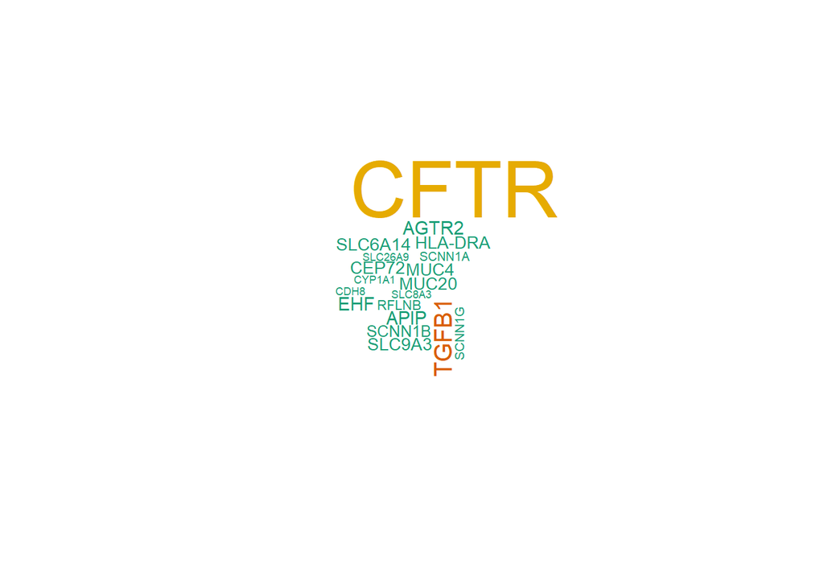

```r
output_gene_prioritization("cystic fibrosis", wordcloud = TRUE, return_output = FALSE)
```

As a new feature, PhenolyzerR can perform gene-disease extension!

```r
autism_extended_genes <- output_gene_prioritization("autism", predict = TRUE)
```

```
## Finished searching the Disease Ontology Database
```

```
## Finished searching the CTD Medic Database
```

```
## Disease term extension completed
```

```
## Matching to database with extended terms!
```

```
## Matching to database with input term!
```

```
## The gene prediction process starts
```

```r
autism_extended_genes
```

| GENE | SCORE | SOURCE |
| --- | --- | --- |
| MECP2 | 1.0000000000 | seed_gene |
| NLGN3 | 0.5444637691 | seed_gene |
| NLGN4X | 0.3966978285 | seed_gene |
| NLGN1 | 0.3587479312 | predicted_gene |
| NLGN2 | 0.3485735708 | predicted_gene |
| NLGN4Y | 0.3149006933 | predicted_gene |
| CEL | 0.1577104440 | predicted_gene |
| PTEN | 0.1438316815 | predicted_gene |
| GLRA1 | 0.1373023694 | predicted_gene |
| SHANK3 | 0.1251280305 | predicted_gene |

[output cut: 7660 more lines]